## Hierarchical Clustering

#### Prep

In order to make, `ggplot` plots of hierarchical cluster, we’ll need the `ggplot` extensions `ggdendro`. If you don’t already have it installed, uncomment the code in the chunk below and install it now.

```r
#install.packages('ggdendro')
```

We’re going to use some simulated data from a normal distribution to demo hierarchical clustering. Run the code in the chunk below before continuing.

```r
set.seed(42)
tibble(x = rnorm(6, mean = 5, sd = 2),
       y = x + runif(6),
       label = c('A', 'B', 'C', 'D', 'E', 'F')) -> clust_demo
```

### Getting the data in the correct format with `dist()`

The clustering algorithm requires a distance matrix. A distance matrix calculates the euclidean distance between every row in the table and returns a distance matrix with the distances between all rows.

We need to convert our data into a distance matrix using the function `dist()`

```r
clust_demo %>%
# make the tibble into a dataframe because we need to make the labels
# into rownames and tibbles don't allow rownames
  as.data.frame() %>%
# turn the data labels into rownames so they're carried through the distance
# matrix and hierarchical clustering calculations
  column_to_rownames('label') %>%
# use dist() to calculate a distance matrix
  dist(.) -> clust_demo_dist
```

### Calculate the clustering with `hclust()`

The `hclust()` function does the hierarchical clustering calculations.

```r
hclust(clust_demo_dist) -> clust_demo_hclust
```

### Base R plot the hierarchical clustering

You can use the base R `plot()` to directly plot the `hclust` object.

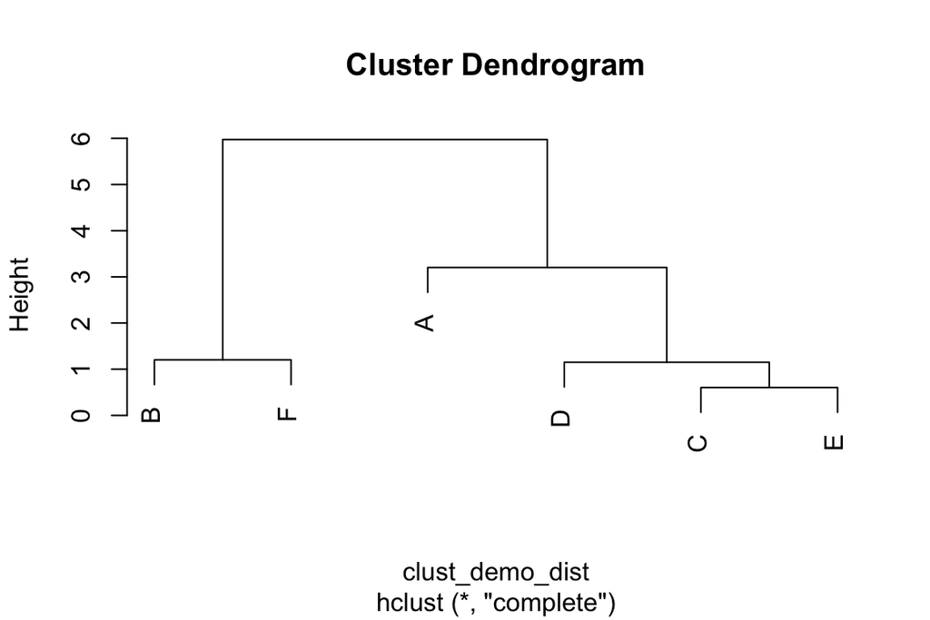

```r
plot(clust_demo_hclust)
```

### Plot hierarchical clustering in `ggplot` using `ggdendro`

It requires more wrangling to plot the `hclust` clustering with ggplot, but the `ggendro` package will do most of the wrangling for us.

```r
# start with the saved hclust object
clust_demo_hclust %>%
# as.dendrogram() turns the hclust results into a special dendrogram class
# that R uses for representing any kind of tree
  as.dendrogram() %>%
# dendro_data() turns the dendrogram class data into numbers that are plottable
  dendro_data() -> clust_demo_ggdendro
```

#### `ggdendrogram()`

Plot using `ggdendro`’s helper function, `ggdendro()`. It plots the dendrogram as a ggplot object.

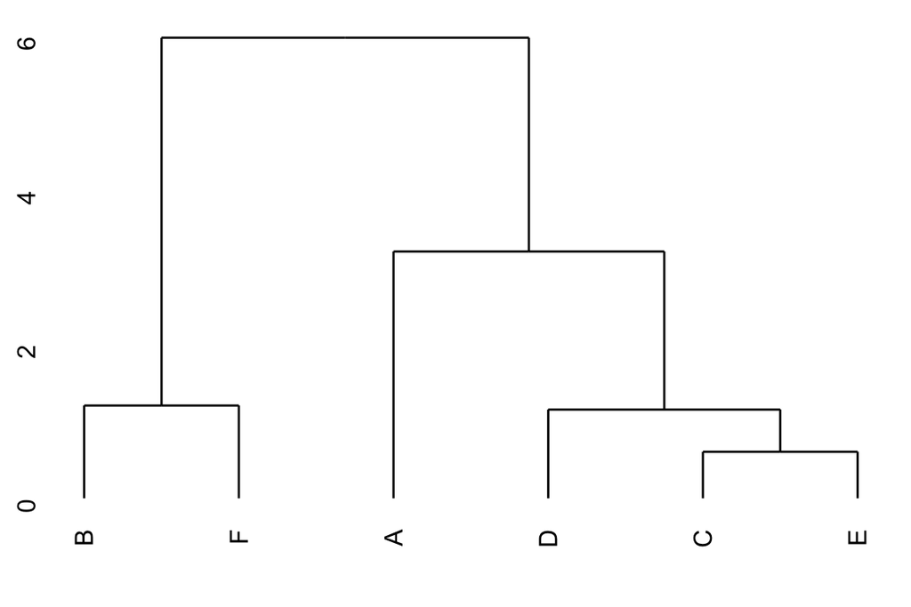

```r
ggdendrogram(clust_demo_ggdendro)
```

You can modify this like any other ggplot plot. For example, I don’t like the y axis labels, so I’ll remove them.

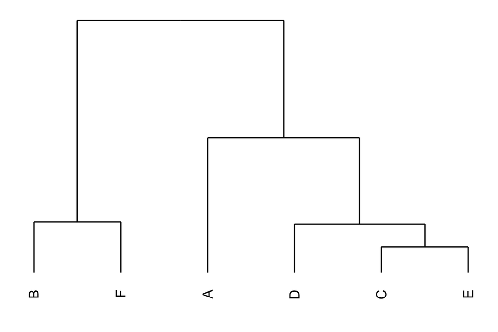

```r
ggdendrogram(clust_demo_ggdendro) +
  theme(axis.text.y = element_blank())
```

#### Plotting the dendrogram with straight `ggplot()`

However, you can’t see (unless you look at the package code) what exact `ggplot` commands `ggdendrogram()` is plotting, which is super annoying when you want to make adjustments to the plot. However, as you can see when you look at the `dendro_data()` table below, all the numbers are there, so we can just plot it ourselves.

```r
clust_demo_ggdendro
```

```
## $segments
##         x         y  xend      yend
## 1  2.6875 5.9744985 1.500 5.9744985
## 2  1.5000 5.9744985 1.500 1.2034621
## 3  1.5000 1.2034621 1.000 1.2034621
## 4  1.0000 1.2034621 1.000 0.0000000
## 5  1.5000 1.2034621 2.000 1.2034621
## 6  2.0000 1.2034621 2.000 0.0000000
## 7  2.6875 5.9744985 3.875 5.9744985
## 8  3.8750 5.9744985 3.875 3.2020659
## 9  3.8750 3.2020659 3.000 3.2020659
## 10 3.0000 3.2020659 3.000 0.0000000
## 11 3.8750 3.2020659 4.750 3.2020659
## 12 4.7500 3.2020659 4.750 1.1513913
## 13 4.7500 1.1513913 4.000 1.1513913
```

[output cut: 25 more lines]

Now we can plot it with `ggplot()`

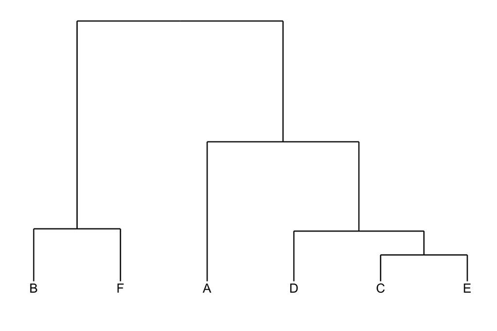

```r
# for once, don't put any data in ggplot() !!!
# the stem and label information is in separate tables, so we want to supply
# separate data to separate geoms
ggplot() +
# the segments table contains the information for plotting branches, so supply
# that to geom_segment() to plot the branches of the tree
  geom_segment(data = clust_demo_ggdendro$segments, aes(x = x, y = y, xend = xend, yend = yend)) +
# the labels table has the labels for the ends of the branches, so supply that
# to geom_text() to label the ends of the branches
  geom_text(data = clust_demo_ggdendro$labels, aes(x = x, y = y, label = label), vjust = 1.25) +
  theme_dendro()
```